# hw4_Rmark

Ruizhou Peng

2023-11-02

load package

```r
library(tidyverse)
```

### 1. probablility theory

#### 1.1 rules of probability

q1: $\mathbb{P}(\{a,b\}) = 0.6, \mathbb{p}(\{b,c\})=0.5\\ so \quad\mathbb{P}(\{c\}) = 0.4,\mathbb{P}(\{a\}) = 0.5, \mathbb{P}(\{b\}) = 0.1$

q2: proof

rule1: $q\in[0,1], so \space \mathbb{P}\ge 0$

rule2: $\Omega = \{0,1\} \quad and \quad \mathbb{P}(\{0,1\})=1 \quad so \space \mathbb{P}(\Omega)=1$

rule3: {$\emptyset$}, {0},{1} are pairwise disjoint and it’s clear that $\mathbb{P}(\cup_{i=1}^4A_i) = \sum_{i=1}^4 \mathbb{P}(A_i)$

#### 1.2 deriving new properties from the rules of probability

q1: union of a finite sequence of disjoint events

proof:

for a finite disjoint sequence A1 to An, for any two events, it has $A_i \cap A_j = \emptyset, \space \mathbb{P}(A_i \cup A_j) = \mathbb{P}(A_i) + \mathbb{P}(A_j) - \mathbb{P}(A_i \cap A_j)$, since $\mathbb{P}(\emptyset) = 0$, so for disjoint events, it has property $\mathbb{P}(A_i \cup A_j)= \mathbb{P}(A_i) + \mathbb{P}(A_j)$. Besides, $A_k \cap (A_i\cup A_j) = \emptyset \quad \mathbb{P}(A_i \cup A_j \cup A_k)= \mathbb{P}(A_i) + \mathbb{P}(A_j) + \mathbb{P}(A_k)$, therefore, $\mathbb{P}(\cup_{i=1}^nA_i)= \sum_{i=1}^n \mathbb{P}(A_i)$

q2: probability of a complement

proof:

for $S \subset \Omega$, $S \cap S^c = \emptyset, S\cup S^c = \Omega$, so S and S<sup>c</sup> are pairwise disjoint. $\mathbb{P}(S\cup S^c)=\mathbb{P}(\Omega)=1=\mathbb{P}(S)+\mathbb{P}(S^c)$ so $\mathbb{P}(S^c) = 1-\mathbb{P}(S)$

q3: the union bound

example:

sample space {a,b,c}

event {(a,b), (a,c)}

p(a) = 0.4, p(b) = 0.1, p(c) = 0.5. S1==>(a,b), S2==>(a,c) $\mathbb{P}(S_1)=0.5, \mathbb{P}(S_2)=0.9$ $\mathbb{P}(\cup_{i=1}^{\infty}S_i) \neq \sum_{i=1}^{\infty}\mathbb{P}(S_i)$

q4:

proof:

for any $x_i \in A \space \& \space x_i\in B$, P(A) + P(B) count $\sum_i\mathbb{P}(x_i)$ twice. $\sum_i\mathbb{P}(x_i)=\mathbb{P}(A\cap B)$, so have to minus one $\mathbb{P}(A\cap B)$

### 2. finite probability spaces

#### 2.1 sampling with replacement

3 red and 7 blue spheres, draw with replacement

q2: write a function **prob_red_spheres** takes z as input and compute the probability out of a total 22

```r
prob_red_spheres <- function(z){
  # z --> the times that draw a red ball
  p <- choose(22,z)*(0.3^z)*(0.7^(22-z))
  return(p)
}

prob_red_spheres(10)
```

```
## [1] 0.05285129
```

q3: create a frame with 2 columns, one for num_reds and one for prob

```r
num_reds <- seq(1,22)
prob <- unlist(map(num_reds, prob_red_spheres))

prob_by_num_reds <- data.frame(num_reds, prob)

prob_by_num_reds %>% head(3)
```

```
##   num_reds        prob
## 1        1 0.003686403
## 2        2 0.016588812
## 3        3 0.047396606
```

q4: display a plot of the probability as a function of the number of reds

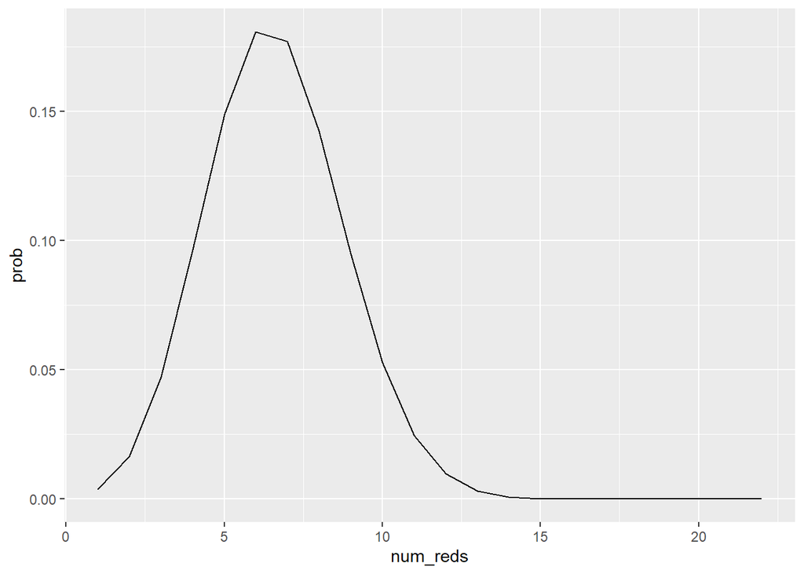

```r
prob_by_num_reds %>%
  ggplot(aes(num_reds, prob))+
  geom_line()
```

q5: explore the **sample** within R, to run an experiment in which we sample with replacement from a collection of 10 objects and repeat 22 times

```r
sample(10,22, replace=TRUE)
```

```
##  [1]  4  3 10  4  6 10  7  7 10  9  6  6  5  6  6  9  5  7 10  4  7  3
```

can use **set.seed** for reproduction

now use **sample** to simulate selecting z red balls from a bag of size 10, with 3 red balls and 7 blue balls, when sampling 22 times with replacement

generate a data frame

```r
num_trials<-1000 # set the number of trials
#set.seed(0) # set the random seed

# generate collection of num_trials simulations
# first column is number of trial
# second column is the result of each trial
# use "map" to map each trial to a list of outcomes
sampling_with_replacement_simulation<-data.frame(trial=1:num_trials) %>%
mutate(sample_balls = map(.x=trial, ~sample(10,22, replace = TRUE)))
```

now add a new column **num_reds** shows the number of red balls, assuming the three red balls are labelled by {1,2,3}

```r
# use "sum" to count the elements number which le 3
sampling_with_replacement_simulation <- sampling_with_replacement_simulation %>%
  mutate(num_reds= map_dbl(.x= sample_balls, ~sum(.x<=3)))
```

q6: now add a new column to **prob_by_num_reds** gives the probability of red balls using the number of times divided by the total number of trials (frequency)，

```r
# first extract the num_reds in each trial
reds_occ_times <- sampling_with_replacement_simulation$num_reds

# calculate correspond frequency with num_reds in prob_by_num_reds

prob_by_num_reds<-prob_by_num_reds%>%
  mutate(predicted_prob=
           map_dbl(.x=num_reds,~sum(.x==reds_occ_times))/num_trials)
```

q7: create a plot comparing the results of simulation with probability formula according to frame **prob_by_num_reds**

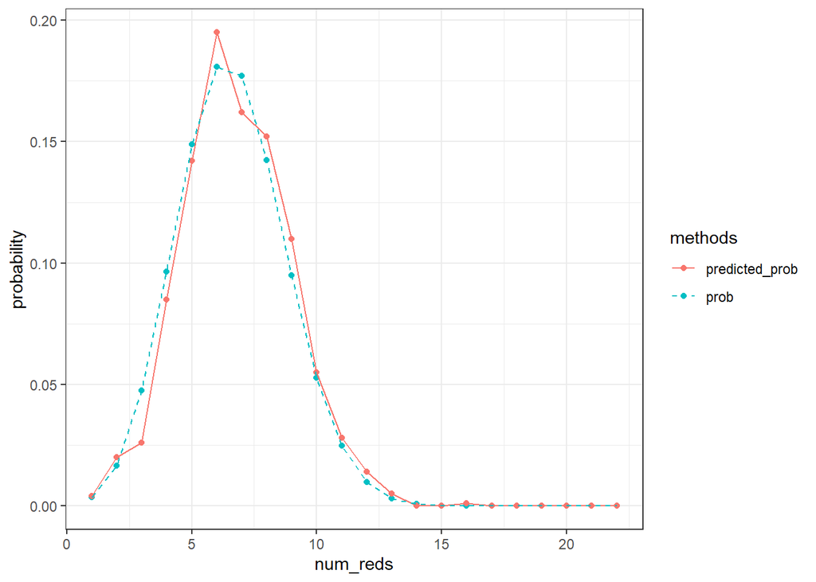

```r
# first tidy frame since simulation and formula can be
# seen as two different estimating methods
prob_by_num_reds_tidy <- prob_by_num_reds%>%
  pivot_longer(cols=!num_reds, names_to = "methods", values_to = "probability")

# then use tidied version to visualize
prob_by_num_reds_tidy%>%
  ggplot(aes(x=num_reds, y=probability, color=methods, linetype=methods))+geom_point()+
  geom_line()+scale_linetype_manual(values = c('solid','dashed'))+theme_bw()
```

#### 2.2 sampling without replacement

suppose we have a large bag containing 100 spheres, 50 red, 30 blue and 20 green. suppose that we sample 10 spheres from the bag without replacement

q1: what is the probability that one or more colors are missing from the selection? answer this question via a simulation study using ideas from the previous question

```r
# set a number for trials
num_trials <- 10000

# create a frame with two columns,one for num, one for simulation result
prob_by_num <- data.frame(number=1:num_trials)%>%
             mutate(result=map(.x=number,
                               ~sample(100,10, replace=FALSE)))

# compute the number of each color in every trial
# suppose green balls [1,20], red [21,70], blue [71,100]
prob_by_num <- prob_by_num%>%
  mutate(green=map_dbl(.x=result, ~sum(.x>=1 & .x <= 20)),
         red=map_dbl(.x=result, ~sum(.x>=21 & .x <= 70)),
         blue=map_dbl(.x=result, ~sum(.x>=71 & .x <= 100)))

# use pmin to compute the minimum ball number appeared
# pmin is compare several vectors' correspond element and
# return a new vector with each element is min
prob_by_num <- prob_by_num %>% mutate(minimum=pmin(green, red, blue))

# compute the proportion of rows which minimum number is zero
proportion <- sum(prob_by_num$minimum==0)/num_trials

proportion
```

```
## [1] 0.1118
```

q2: derive a mathematical expression for the probability

draw 10 balls without replacement equals draw at one time,to compute the probability of missing color, it has two possible result: missing one color or missing two

first compute missing one color

$\mathbb{P}_{red} = \frac{{50\choose{10}}}{{100\choose{10}}}$[subscript means missing]

$\mathbb{P}_{green} = \frac{{80\choose{10}}}{{100\choose{10}}}$

$\mathbb{P}_{blue} = \frac{{70\choose{10}}}{{100\choose{10}}}$

then compute missing two colors

$\mathbb{P}_{red} = \frac{{50\choose{10}}}{{100\choose{10}}}$[subscript means only having]

$\mathbb{P}_{green} = \frac{{20\choose{10}}}{{100\choose{10}}}$

$\mathbb{P}_{blue} = \frac{{30\choose{10}}}{{100\choose{10}}}$

attention! the formula of missing one color indicating the possible of missing two, so the add of probability of missing one count missing two colors twice, so we need to minus missing two.

so the result is

```r
# compute the result of formula

prob_formula <- (choose(50,10)*2+choose(80,10)+choose(70,10)-choose(50,10)-choose(20,10)-choose(30,10))/choose(100,10)

prob_formula
```

```
## [1] 0.1186252
```

use plot to visualize

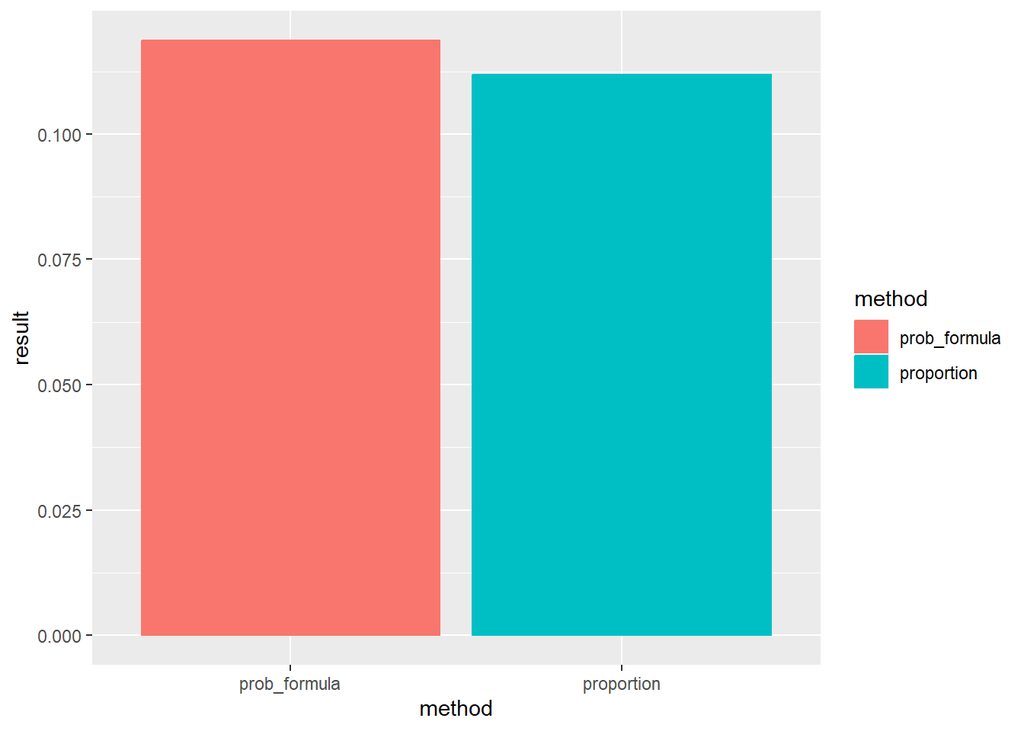

```r
# there are difference between geom_bar and geom_col
# bar shows the proportion to the number of cases
# col shows the values in the data, in this case, it's result
method <- c('prob_formula', 'proportion')
result <- c(prob_formula, proportion)
df<- data.frame(method, result)
df%>%ggplot(aes(x=method,y=result, color=method, fill=method))+geom_col()
```